# TITANIC DATASET COMPLETE ANALYSIS BY ARMAN RAWAL

## Importing the Dataset and Libraries

```python
import pandas as pd
import numpy as np
import matplotlib.pyplot as plt
%matplotlib inline
import seaborn as sns
```

### Importing the data

**Some containers I have made to store data over which will you gonna see in future**

**df = Titanic-Dataset.csv**

```python
df = pd.read_csv('Titanic-Dataset.csv', encoding = 'unicode_escape')
```

```python
df.head()
```

|  | PassengerId | Survived | Pclass | Name | Sex | Age | SibSp | Parch | Ticket | Fare | Cabin | Embarked |
| --- | --- | --- | --- | --- | --- | --- | --- | --- | --- | --- | --- | --- |
| 0 | 1 | 0 | 3 | Braund, Mr. Owen Harris | male | 22.0 | 1 | 0 | A/5 21171 | 7.2500 | NaN | S |
| 1 | 2 | 1 | 1 | Cumings, Mrs. John Bradley (Florence Briggs Th... | female | 38.0 | 1 | 0 | PC 17599 | 71.2833 | C85 | C |
| 2 | 3 | 1 | 3 | Heikkinen, Miss. Laina | female | 26.0 | 0 | 0 | STON/O2. 3101282 | 7.9250 | NaN | S |
| 3 | 4 | 1 | 1 | Futrelle, Mrs. Jacques Heath (Lily May Peel) | female | 35.0 | 1 | 0 | 113803 | 53.1000 | C123 | S |
| 4 | 5 | 0 | 3 | Allen, Mr. William Henry | male | 35.0 | 0 | 0 | 373450 | 8.0500 | NaN | S |

#### Here, I managed and analyzed something and should be know to you.

**Survived: Indicates whether the passenger survived or not 0 = No, 1 = Yes.**

**Pclass: The passenger class, indicating the socio-economic status of the passenger 1 = 1st Class , 2 = Middle Class, 3 = 3rd Class.**

**SibSp: The number of siblings or spouses aboard the Titanic.**

**Parch: The number of parents or children aboard the Titanic.**

**Embarked: The port of locations for the passenger C = Cherbourg, Q = Queenstown, S = Southampton.**

## Data Modeling & Data Manipulation

```python
pd.isnull(df).sum()
```

```
PassengerId      0
Survived         0
Pclass           0
Name             0
Sex              0
Age            177
SibSp            0
Parch            0
Ticket           0
Fare             0
Cabin          687
Embarked         2
dtype: int64
```

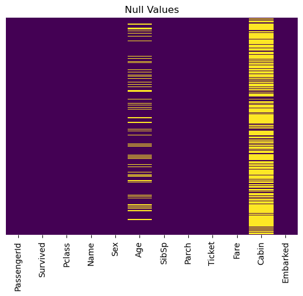

```python
sns.heatmap(df.isnull(),yticklabels = False, cbar = False, cmap = 'viridis')
plt.title('Null Values')
```

**Here, We can see two columns(Age & Cabin) which are having enormous no. of null values Let's first consider the Age column because we can easily find them basis on the Mean and some statistics analysis.**

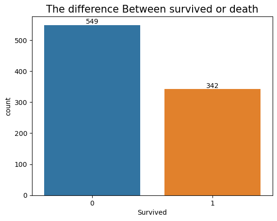

```python
ax = sns.countplot(x ='Survived', data =df)
for bars in ax.containers:
    ax.bar_label(bars)
plt.title('The difference Between survived or death', fontsize = 15)
```

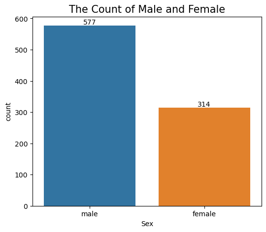

```python
plt.figure(figsize = (6,5))
ax = sns.countplot(x ='Sex',data = df)
for bars in ax.containers:
    ax.bar_label(bars)
plt.title('The Count of Male and Female', fontsize = 15)
```

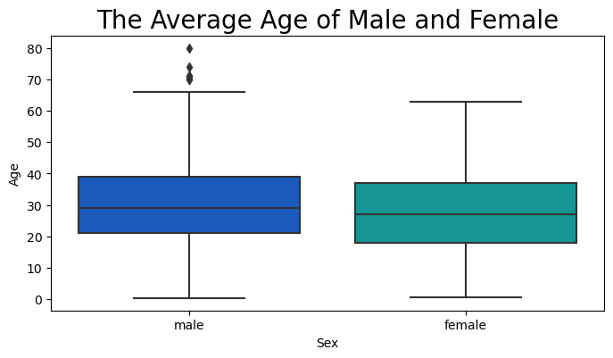

```python
plt.figure(figsize = (8,4))
sns.boxplot(x ='Sex', y='Age',data= df, palette = 'winter')
plt.title('The Average Age of Male and Female', fontsize = 20)
```

**By Analyzing data with Age and Sex. Over here we can make a judgment that average of Male(29.5) and female(28).**

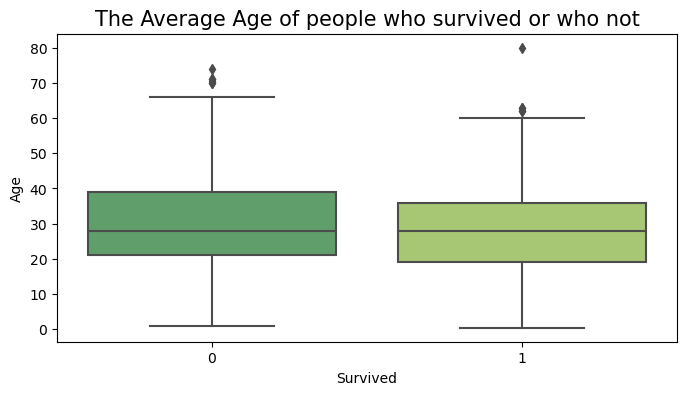

```python
plt.figure(figsize = (8,4))
sns.boxplot(x ='Survived', y='Age',data= df, palette = 'summer')
plt.title('The Average Age of people who survived or who not', fontsize = 15)
```

**Here We cannot consider Survived and Age data. By getting their Average because it's almost same**

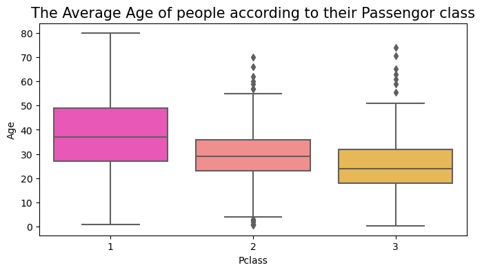

```python
plt.figure(figsize = (8,4))
sns.boxplot(x ='Pclass', y='Age',data= df, palette = 'spring')
plt.title('The Average Age of people according to their Passengor class', fontsize = 15)
```

**Here, I'm gonna consider this table information as to fill blanks of Age column because here is almost three different averages we got from the data Pclass column which represents average 1 = 38 , 2 = 29.5 and 3 = 24.5.**

```python
def impute_age(cols):
    Age = cols.iloc[0]
    Pclass = cols.iloc[1]

    if pd.isnull(Age):

        if Pclass == 1:
            return 38

        elif Pclass == 2:
            return 29.5

        elif Pclass == 3:
            return 24.5
    else:
        return Age
```

```python
df['Age'] = df[['Age', 'Pclass']].apply(impute_age, axis=1)
```

```python
pd.isnull(df).sum()
```

```
PassengerId      0
Survived         0
Pclass           0
Name             0
Sex              0
Age              0
SibSp            0
Parch            0
Ticket           0
Fare             0
Cabin          687
Embarked         2
dtype: int64
```

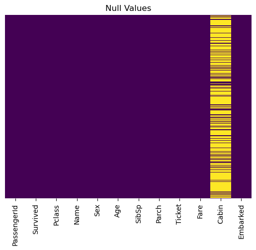

```python
sns.heatmap(df.isnull(),yticklabels = False, cbar = False, cmap = 'viridis')
plt.title('Null Values')
```

**As I can see here there is a lot data missing from the Cabin. and every Cabin is allotted differently. Therefore, drop the Column is best move to go further.**

```python
df.drop(['Cabin'],axis = 1, inplace = True)
```

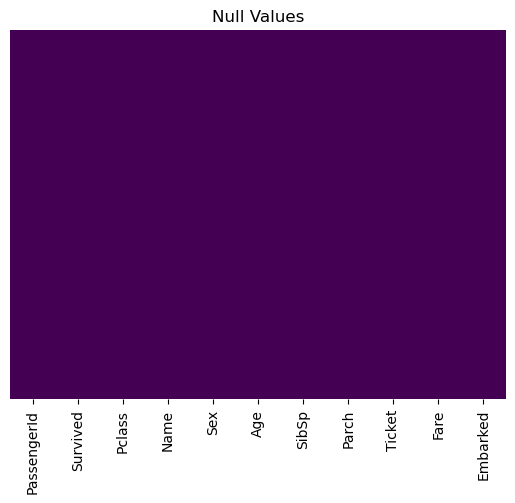

```python
sns.heatmap(df.isnull(),yticklabels = False, cbar = False, cmap = 'viridis')
plt.title('Null Values')
```

# Exploratory Data Analysis

**To go further we need to drop some informations from the data such as column which are not useful for our analysis**

```python
new_data = df.drop(['PassengerId','Name','Ticket'],axis = 1)
```

```python
new_data.head(10)
```

[output not shown]

```python
new_data.info()
```

```
<class 'pandas.core.frame.DataFrame'>
RangeIndex: 891 entries, 0 to 890
Data columns (total 8 columns):
 #   Column    Non-Null Count  Dtype
---  ------    --------------  -----
 0   Survived  891 non-null    int64
 1   Pclass    891 non-null    int64
 2   Sex       891 non-null    object
 3   Age       891 non-null    float64
 4   SibSp     891 non-null    int64
 5   Parch     891 non-null    int64
 6   Fare      891 non-null    float64
 7   Embarked  889 non-null    object
dtypes: float64(2), int64(4), object(2)
memory usage: 55.8+ KB
```

```python
new_data.describe()
```

|  | Survived | Pclass | Age | SibSp | Parch | Fare |
| --- | --- | --- | --- | --- | --- | --- |
| count | 891.000000 | 891.000000 | 891.000000 | 891.000000 | 891.000000 | 891.000000 |
| mean | 0.383838 | 2.308642 | 29.182570 | 0.523008 | 0.381594 | 32.204208 |
| std | 0.486592 | 0.836071 | 13.237785 | 1.102743 | 0.806057 | 49.693429 |
| min | 0.000000 | 1.000000 | 0.420000 | 0.000000 | 0.000000 | 0.000000 |
| 25% | 0.000000 | 2.000000 | 22.000000 | 0.000000 | 0.000000 | 7.910400 |
| 50% | 0.000000 | 3.000000 | 26.000000 | 0.000000 | 0.000000 | 14.454200 |
| 75% | 1.000000 | 3.000000 | 37.000000 | 1.000000 | 0.000000 | 31.000000 |
| max | 1.000000 | 3.000000 | 80.000000 | 8.000000 | 6.000000 | 512.329200 |

```python
new_data[['Age', 'Fare']].describe()
```

|  | Age | Fare |
| --- | --- | --- |
| count | 891.000000 | 891.000000 |
| mean | 29.182570 | 32.204208 |
| std | 13.237785 | 49.693429 |
| min | 0.420000 | 0.000000 |
| 25% | 22.000000 | 7.910400 |
| 50% | 26.000000 | 14.454200 |
| 75% | 37.000000 | 31.000000 |
| max | 80.000000 | 512.329200 |

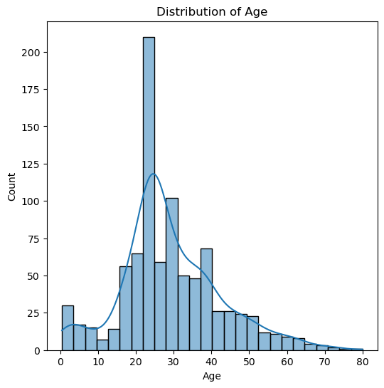

```python
plt.figure(figsize=(6, 6))
sns.histplot(df['Age'], kde=True)
plt.title('Distribution of Age')
```

**By analyzing the Distribution of Age and majority of people belongs to 20 to 30 Age group**

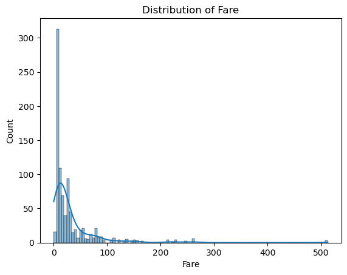

```python
sns.histplot(df['Fare'], kde=True)
plt.title('Distribution of Fare')
```

**By Analyzing the Distribution of Fare. Most people bought 0-100 group amount of Fare for the Titanic.For more analyzing Fare its better to bifurcate on the basis of Passenger Class**

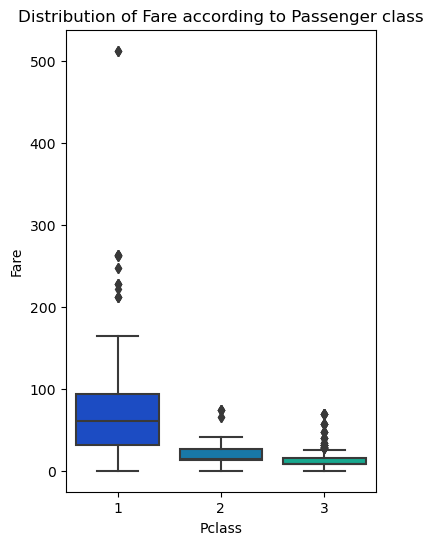

```python
plt.figure(figsize=(4, 6))
sns.boxplot(x = 'Pclass' , y = 'Fare', data = new_data,palette = 'winter')
plt.title('Distribution of Fare according to Passenger class')
```

**Here the Average of Fare according to Passenger class**

```python
new_data['Fare'] = new_data['Fare'].astype('int')
```

```python
new_data.groupby(['Survived','Embarked'],as_index = False)['Fare'].sum().sort_values( by = 'Fare' , ascending = False)
```

|  | Survived | Embarked | Fare |
| --- | --- | --- | --- |
| 2 | 0 | S | 8684 |
| 5 | 1 | S | 8501 |
| 3 | 1 | C | 7375 |
| 0 | 0 | C | 2625 |
| 1 | 0 | Q | 599 |
| 4 | 1 | Q | 377 |

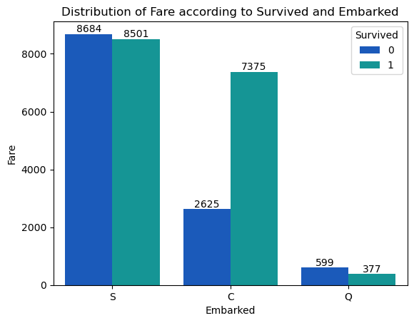

```python
new_data['Survived'] = new_data['Survived'].astype(str)
new = new_data.groupby(['Survived','Embarked'],as_index = False)['Fare'].sum().sort_values( by = 'Fare' , ascending = False)
ax = sns.barplot(x='Embarked', y='Fare', hue='Survived', data=new, palette = 'winter')
for bars in ax.containers:
    ax.bar_label(bars)
plt.title('Distribution of Fare according to Survived and Embarked')
```

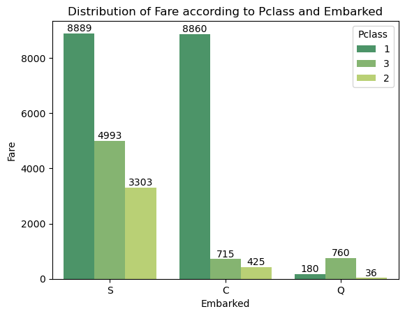

```python
new_data['Pclass'] = new_data['Pclass'].astype(str)
new = new_data.groupby(['Pclass','Embarked'],as_index = False)['Fare'].sum().sort_values( by = 'Fare' , ascending = False)
ax = sns.barplot(x='Embarked', y='Fare', hue='Pclass', data=new, palette = 'summer')
for bars in ax.containers:
    ax.bar_label(bars)
plt.title('Distribution of Fare according to Pclass and Embarked')
```

**Let's Find out The people who are traveled S,C and Q. Bifurgate them on the basis of age.**

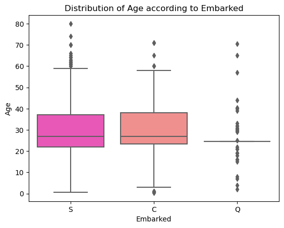

```python
ax = sns.boxplot(x = 'Embarked',y= 'Age' , data = new_data , palette = 'spring')
plt.title('Distribution of Age according to Embarked')
```

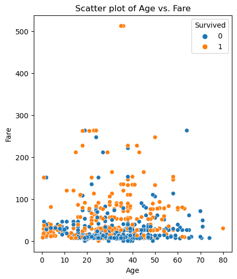

```python
plt.figure(figsize=(5,6))
sns.scatterplot(data=new_data, x='Age', y='Fare', hue='Survived')
plt.title('Scatter plot of Age vs. Fare')
```

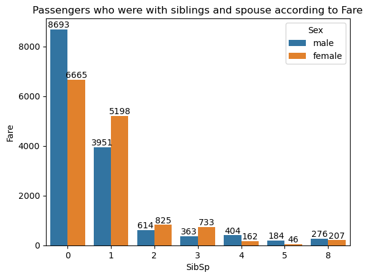

```python
new = new_data.groupby(['Sex','SibSp'],as_index = False)['Fare'].sum().sort_values( by = 'Fare' , ascending = False)
ax = sns.barplot(x='SibSp', y='Fare', hue='Sex', data=new)
for bars in ax.containers:
    ax.bar_label(bars)
plt.title('Passengers who were with siblings and spouse according to Fare')
```

**Here, We can identify that most of the passengers wer single they Might be crew members of the ship**

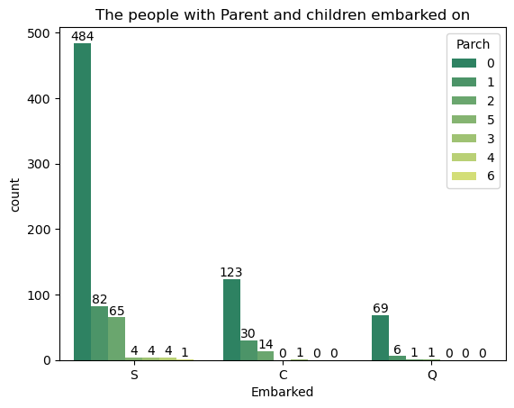

```python
new_data['Parch'] = new_data['Parch'].astype('str')
ax = sns.countplot( x = 'Embarked',hue = 'Parch', data = new_data, palette ='summer')
for bars in ax.containers:
    ax.bar_label(bars)
plt.title('The people with Parent and children embarked on')
```

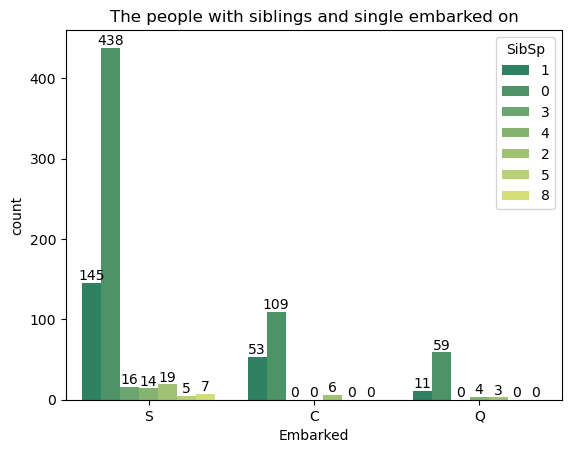

```python
new_data['SibSp'] = new_data['SibSp'].astype('str')
ax = sns.countplot( x = 'Embarked',hue = 'SibSp', data = new_data, palette ='summer')
for bars in ax.containers:
    ax.bar_label(bars)
plt.title('The people with siblings and single embarked on')
```

**By analyzing charts 'The people with siblings and single embarked on' and 'The people with Parent and children embarked on'. I say that People who were travelled single were from S and they might be crewmmembers of the ship I'm not saying all of them but still there might be some possiblities.**

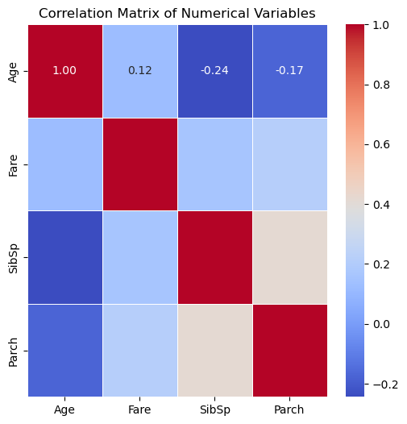

```python
numerical_cols = ['Age', 'Fare', 'SibSp', 'Parch']
corr = df[numerical_cols].corr()
plt.figure(figsize=(6, 6))
sns.heatmap(corr, annot=True, cmap='coolwarm', fmt=".2f", linewidths=0.5)
plt.title('Correlation Matrix of Numerical Variables')
```

# CONCLUSION

**In analyzing the Titanic dataset, several key observations emerged. Imputation of missing age values was conducted, predominantly relying on mean values stratified by passenger class. Notably, the cabin column, due to extensive missingness, was deemed unsuitable for analysis and thus dropped from consideration.**

**Exploration of passenger age distribution revealed a predominant concentration between the ages of 20 and 30. Concurrently, examination of fare distribution elucidated that a significant portion of passengers paid fares ranging from 0 to 100, with variability based on embarkation port and passenger class.**

**Correlation analysis underscored weak associations between age, fare, and familial companionship indicators such as the number of siblings/spouses and parents/children aboard. These insights contribute to a nuanced understanding of passenger demographics and socioeconomic dynamics aboard the Titanic, enriching historical comprehension of this seminal event.**